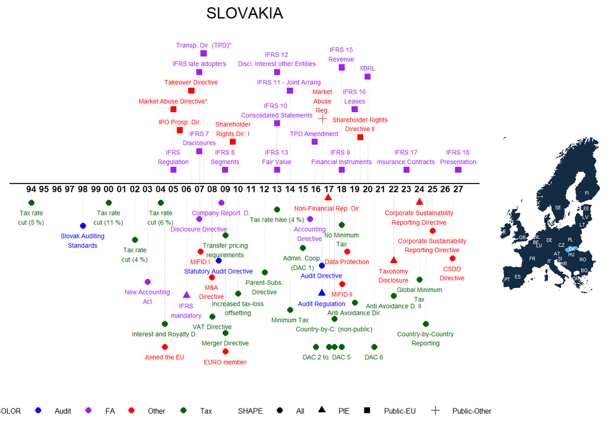

Notes: The graph depicts major regulatory changes that we identified via an extensive literature search, an online survey of mentioned authors, and other sources. Please note that the graph does not include all possible regulatory changes, e.g. minor revisions to local GAAP or tax rate changes below 3% are not included. The dates of EU Directives are based on the official transposition deadlines unless denoted with a *, in which case we included the entry-to-force date as identified in the literature. For more information, please go to [Labro and Pierk (2025)](https://link.springer.com/article/10.1007/s11142-025-09909-0). We kindly ask that you cite the paper if you use the information on this website in your research project. Do you have comments or see anything missing? Please email us!

## Regulations, Publications, Further Graphs

The tab ‘Regulations’ includes links to the regulations, gives short descriptions, and provides selective papers for further reading. If the regulation is a national transposition of an EU Directive, the link to the Directive is given. The tab ‘Number of Regulations’ shows graphically the number of regulations 8 years around the respective year (-4,-3,-2,-1,0,+1,+2,+3). The tab ‘Number of Categories” shows graphically the number of different categories 8 years around the respective year (-4,-3,-2,-1,0,+1,+2,+3). The tab ’Publications’ shows all publications that include the countries’ names and variations thereof in the title, abstract, or keywords. Similarly, the tab ‘SSRN’ shows papers of the SSRN Accouning Research Network that include the countries’ names and variations.

### Regulations

|  | Date | Milestones | Applies_to | Category | Description |
| --- | --- | --- | --- | --- | --- |
| 1 | 1994-01-01 | Tax rate cut (5 %) | All Firms | Tax | Tax rate cut (5 %): Slovakia reduced the corporate tax rate by 5 percentage points (from 45 to 40 percent). |
| 2 | 1998-01-01 | Slovak Auditing Standards | All Firms | Audit | SAUŠ - Slovenské audítorské štandardy (Slovak Auditing Standards): Slovak Auditing Standards became obligatory for all auditors. See also: Daniel, Suranova, and De Beelde 2001 |
| 3 | 2000-01-01 | Tax rate cut (11 %) | All Firms | Tax | Tax rate cut (11 %): Slovakia reduced the corporate tax rate by 11 percentage points (from 40 to 29 percent). |
| 4 | 2002-01-01 | Tax rate cut (4 %) | All Firms | Tax | Tax rate cut (4 %): Slovakia reduced the corporate tax rate by 4 percentage points (from 29 to 25 percent). |
| 5 | 2003-01-01 | New Accounting Act | All Firms | FA | Accounting Act No. 431/2002 (Accounting Act No. 431/2002): Replaces the "old" Accounting Act No. 563/1991. See also: Rykaczewski, Thevenot, and Vulcheva 2022 |
| 6 | 2004-01-01 | Tax rate cut (6 %) | All Firms | Tax | Tax rate cut (6 %): Slovakia reduced the corporate tax rate by 6 percentage points (from 25 to 19 percent). |
| 7 | 2004-05-01 | Joined the EU | All Firms | Other | Joined the EU: Joined the European Union on May 1st, 2004 |
| 8 | 2004-05-01 | Interest and Royalty D. | All Firms | Tax | Zákon č. 659/2004 Z. z., ktorým sa mení a dopĺňa zákon č. 595/2003 Z. z. o dani z príjmov v znení neskorších predpisov /// Zákon č. 621/2007 Z. z., ktorým sa mení a dopĺňa zákon č. 595/2003 Z. z. o da… |
| 9 | 2005-01-01 | IFRS Regulation | Public-EU | FA | Regulation 1606/2002: Firms listed on EU-regulated markets are required to use the International Financial Reporting Standards (IFRS) for their consolidated financial statements. Firms that use US GAA… |
| 10 | 2005-01-01 | Market Abuse Directive | Public-EU | Other | Zákon č. 635/2004 Z. z., ktorým sa mení a dopĺňa zákon č. 566/2001 Z. z. o cenných papieroch a investičných službách a o zmene a doplnení niektorých zákonov (zákon o cenných papieroch) v znení neskorš… |

[output cut: 56 more lines]

### Number of Regulations

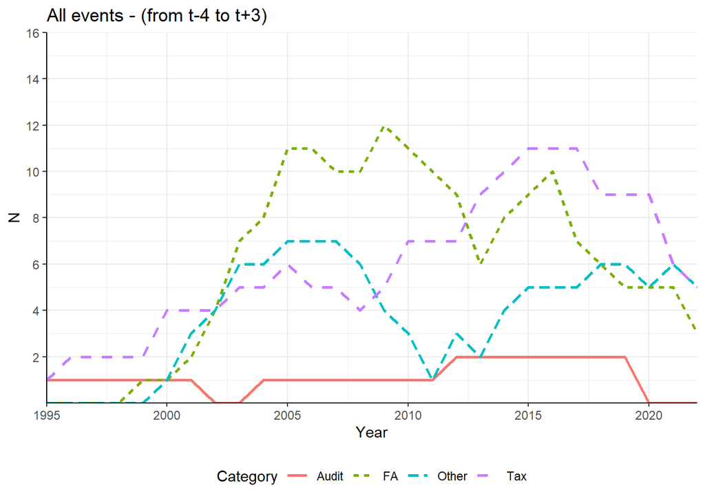

### Number of Categories

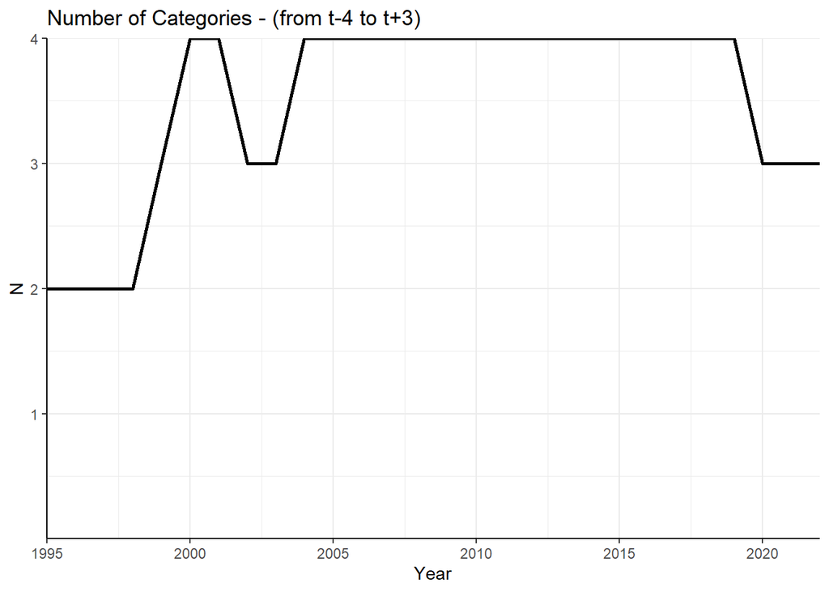

### Publications

|  | authors | title | year | journal |
| --- | --- | --- | --- | --- |
| 1 | Bonsón E., Escobar T. | digital reporting in eastern europe: an empirical study | 2006 | International Journal of Accounting Information Systems |
| 2 | Daniel P., Suranova Z., De Beelde I. | the development of accounting in slovakia | 2001 | European Accounting Review |
| 3 | Sucher P., Seal W., Zelenka I. | true and fair in the czech republic: a note on local perceptions | 1996 | European Accounting Review |

### SSRN

|  | authors | title | Posted | Revised |
| --- | --- | --- | --- | --- |
| 1 | Jaroslav Bukovina, Tomas Lichard, Jan Palguta and Branislav Zudel | tax reforms and inter-temporal shifting of corporate income: evidence from tax records in slovakia | 2020-10-27 | 2021-02-24 |